# STAT385 Notes

## Fri Jan 24 2020

#### Rolling Dice

Simple function that simulates rolling of two dice and prints the sum of the two dice.

```r
roll <- function(){
  die <- 1:6
  dice <- sample(die, size = 2, replace = T)
  sum(dice)
}
roll()
```

```
[1] 8
```

Arguments can change in a function. Say if we want to roll a d20, we can include a function argument.

```r
roll2 <- function(sides){
  dice <- sample(x = sides, size = 1)
  dice
}
roll2(1:20)
```

```
[1] 14
```

*The argument sides can be changed to change the number of sides on the die*

#### Now let’s roll some *weighted* dice

Look in ?sample to see if you can change the probability of a sample using argument ‘prob =’

```r
weighted_roll <- function(){
  die <- 1:6
  dice = sample(die, size = 2 , replace = T, prob = c(1/8,1/8,1/8,1/8,1/8,4/8))
  sum(dice)
}
weighted_roll()
```

```
[1] 5
```

The argument ‘prob =’ allows you to change the probabilities of the die appearing in each roll. In this case, 1:5 have a probability of 1/8, and 6 has a probability of 4/8.

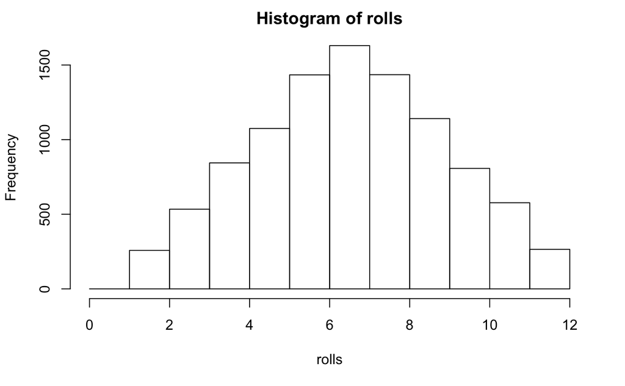

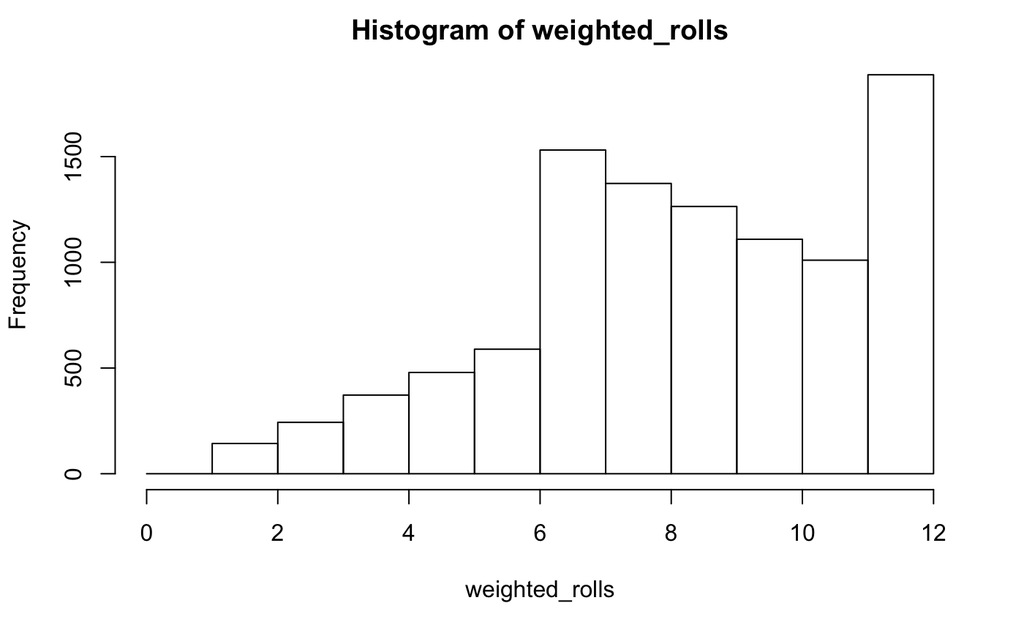

To look at the results, simulate the rolls 10000 times and plot the histogram. Look at how the weighted rolls has shifted the histogram.

**You don’t have to use argument names, but if you do, order doesn’t matter** *sample(1:6, 2, c(1,1,1,1,2,2))* wont work because the probability vector is in the spot for replace. The argument replace can only take args ‘T’ and ‘F’.

```r
sample(1:6, 2, c(1,1,1,1,2,2))
```

```
Error in sample.int(length(x), size, replace, prob) :
  invalid 'replace' argument
```

## Mon Jan 27 2020

#### Double Vetor

Double means regular number, also called numeric. R will store any number you type in R as double vector of length 1.

```r
4.5
```

```
[1] 4.5
```

```r
is.vector(4.5)
```

```
[1] TRUE
```

Variable `die` is a double vector of length 6.

Integer refers to numbers that can be written withoug a decimal component. By default, R stores any number as double.

There are many different types of data. Character is denoted by " " or ‘’. Complex vectors can store complex numbers by `complex`.

Raw vectors can store raw bytes of data with `raw`.

#### Lists

Lists group data into a one-dimensional array. Group R objects such as atomic vecotrs and other lists.

```r
my_vector <- c(1,"one",TRUE)
my_vector
```

```
[1] "1"    "one"  "TRUE"
```

```r
my_list <- list(1, "one", TRUE)
my_list
```

```
[[1]]
[1] 1

[[2]]
[1] "one"

[[3]]
[1] TRUE
```

`list()` creates a list the same way as `c()` creates a vector. ELements in a list can have different lenghts, dimensions, or types of objects.

```r
big_list <- list(1:12, "2020", list("january", 2:8))
big_list
```

```
[[1]]
 [1]  1  2  3  4  5  6  7  8  9 10 11 12

[[2]]
[1] "2020"

[[3]]
[[3]][[1]]
[1] "january"

[[3]][[2]]
[1] 2 3 4 5 6 7 8
```

This list features a double vector of length 12, a character vector of length one, and a list with two sub elements, a character vector of length 1 and a numeric vector of length 7.

Many sublists can be created using the `list()` function. This next list features two main elements, with multiple sub elements.

```r
instructor <- list("Ha", 24)
students <- list(list("Alex", 20), list("Dave", 21))
stat385 <- list(instructor, students)
stat385
```

```
[[1]]
[[1]][[1]]
[1] "Ha"

[[1]][[2]]
[1] 24


[[2]]
[[2]][[1]]
[[2]][[1]][[1]]
[1] "Alex"

[[2]][[1]][[2]]
[1] 20


[[2]][[2]]
[[2]][[2]][[1]]
[1] "Dave"

[[2]][[2]][[2]]
[1] 21
```

##### How do you select elements from a list?

Selecting an element from a vector uses a single bracket. `[]`. For a list, use a double bracket `[[]]`.

```r
big_list[1]
```

```
[[1]]
 [1]  1  2  3  4  5  6  7  8  9 10 11 12
```

```r
big_list[[1]]
```

```
 [1]  1  2  3  4  5  6  7  8  9 10 11 12
```

Compare the following code segments:

```r
big_list[[3]]
```

```
[[1]]
[1] "january"

[[2]]
[1] 2 3 4 5 6 7 8
```

```r
big_list[[3]][1]
```

```
[[1]]
[1] "january"
```

The first line pulls out the entire third element from the list. The following line pulls out only the first element of the sublist, character vector `"january"`.

Using `[[]]` and `[]`, we can access any element in a list. Let’s look at Alex’s information.

```r
stat385[[2]][[1]]
```

```
[[1]]
[1] "Alex"

[[2]]
[1] 20
```

```r
stat385[[2]][[1]][[1]]
```

```
[1] "Alex"
```

You have to build step by step in order to find what you’re looking for. How would we find Ha’s age in `stat385`?

```r
stat385[[1]][[2]]
```

```
[1] 24
```

#### Matrix

Matrix stores values of the same data type in a two dimensional array.

```r
m <- matrix(data = die, nrow = 2)
m
```

```
     [,1] [,2] [,3]
[1,]    1    3    5
[2,]    2    4    6
```

To create a matrix, supply `matrix()` with an atomic vector to reorganzie and specify number of rows, columns, or rows and columns using `nrow =` and `ncol =`.

By default, `matrix()` will fill the matrix column by column. Fill the matrix row by row with `byrow =T`.

```r
m <- matrix(data = die, nrow = 2, byrow = T)
m
```

```
     [,1] [,2] [,3]
[1,]    1    2    3
[2,]    4    5    6
```

##### How do we select objects of a matrix?

To select elemnts in a matrix, use `[ , ]`. `[row, column]`. Leave one element blank to extract an entire row or column.

```r
m
```

```
     [,1] [,2] [,3]
[1,]    1    2    3
[2,]    4    5    6
```

```r
m[1,2]
```

```
[1] 2
```

```r
m [2, 3]
```

```
[1] 6
```

```r
m[1, ]
```

```
[1] 1 2 3
```

```r
m[, 3]
```

```
[1] 3 6
```

The output is a vector.

To select a smaller sub matrix, use `[ : , : ]`.

```r
m[1:2,1:2]
```

```
     [,1] [,2]
[1,]    1    2
[2,]    4    5
```

This outputs a matrix.

#### Array

The `array()` funciton creates an n-dimensional array.

```r
my_array <- array(data = 1:12, dim = c(2,6))
my_array
```

```
     [,1] [,2] [,3] [,4] [,5] [,6]
[1,]    1    3    5    7    9   11
[2,]    2    4    6    8   10   12
```

`my_array` is a two-dimensional array, which is a matrix. What about a three-dimensional array?

```r
my_array <- array(data = 1:12, dim = c(2,2,3))
my_array
```

```
, , 1

     [,1] [,2]
[1,]    1    3
[2,]    2    4

, , 2

     [,1] [,2]
[1,]    5    7
[2,]    6    8

, , 3

     [,1] [,2]
[1,]    9   11
[2,]   10   12
```

##### How do we select dimensions in an array? Similar to matrix, we use `[ , ,]`.

```r
my_array[1,1,1]
```

```
[1] 1
```

```r
my_array[,,1]
```

```
     [,1] [,2]
[1,]    1    3
[2,]    2    4
```

```r
my_array[,1,1]
```

```
[1] 1 2
```

#### Summary of data types

1. Elements of an atomic vecotr, matrix, or array have to be of same data type
2. Elements of a list can be different R objects,
3. Atomic Vector and list store data in one-dimensional array.
4. Matrix stores data in a two-dimensional array.
5. Array can store data in an n-dimensional array.

##### What is the difference between data types and R objects?

1. Data types: basic elements of a programming language
   1. Think double, integer, character, logical, etc.
2. R objects: bigger structures
   1. Think atomic vector, list, matrix, etc.

#### Attributes

Attributes tell us information about R objects.

`name()` allows us to name objects, and `dim()` allows us to set object dimensions.

## Wed Jan 29 2020

#### Excercise 1

```r
roll_dice <- function(){
  die <- 1:6
  dice <- sample(die, size = 6, replace = T)
  mean(dice)
}
roll_dice()
```

```
[1] 4.333333
```

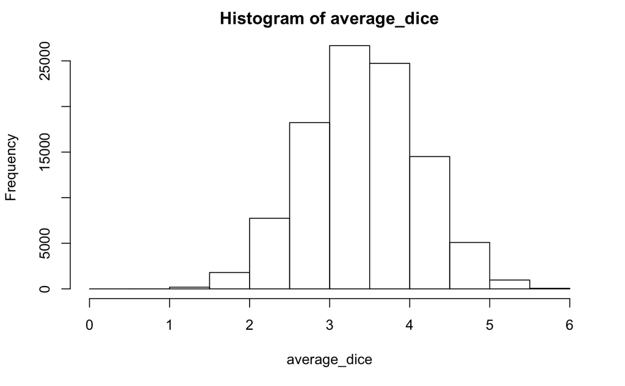

```r
average_dice <- replicate(n = 100000, expr = roll_dice())
hist(x = average_dice, breaks = seq(from = 0, to = 6, by = 0.5))
```

#### Excercise 2

```r
roll_two <- function(red, green){
  if(missing(red)){
    red = 6
  }
  if(missing(green)){
    green = 6
  }
  red_die <- 1:red
  green_die <- 1:green
  red_roll <- sample(red_die, 1)
  green_roll <- sample(green_die, 1)
  out <- list(red_roll, green_roll, red_roll >= green_roll)
  print(out)
}
roll_two()
```

```
[[1]]
[1] 3

[[2]]
[1] 3

[[3]]
[1] TRUE
```

#### Excercise 3

```r
instructor <- list("Ha", 24)
students <- list(list("Alex", 20), list("Dave", 21))
stat385 <- list(instructor, students)
stat385
```

```
[[1]]
[[1]][[1]]
[1] "Ha"

[[1]][[2]]
[1] 24


[[2]]
[[2]][[1]]
[[2]][[1]][[1]]
[1] "Alex"

[[2]][[1]][[2]]
[1] 20


[[2]][[2]]
[[2]][[2]][[1]]
[1] "Dave"

[[2]][[2]][[2]]
[1] 21
```

Alex’s age

```r
stat385[[2]][[1]][[2]]
```

```
[1] 20
```

List of David’s name and age

```r
stat385[[2]][[2]]
```

```
[[1]]
[1] "Dave"

[[2]]
[1] 21
```

Ha’s Name

```r
stat385[[1]][[1]]
```

```
[1] "Ha"
```

#### Excercise 4

```r
m <- matrix(data = 1:16, nrow = 4, byrow = TRUE)
m
```

```
     [,1] [,2] [,3] [,4]
[1,]    1    2    3    4
[2,]    5    6    7    8
[3,]    9   10   11   12
[4,]   13   14   15   16
```

Get the element on the 1st row, 3rd column.

Get the element on the 3rd row, 2nd column.

Get all the elements from the 1st row.

Get all the elements from the 3rd column.

Compute the sum of all the elements from the 1st row.

Compute the average of all the elements from the 3rd column.

```r
m[1,3]
```

```
[1] 3
```

```r
m[3,2]
```

```
[1] 10
```

```r
m[1, ]
```

```
[1] 1 2 3 4
```

```r
m[ ,3]
```

```
[1]  3  7 11 15
```

```r
sum(m[1,])
```

```
[1] 10
```

```r
mean(m[,3])
```

```
[1] 9
```